# Summary Statistics, Factors, Dataframes and Lists

Ic3fr0g

2018-02-01

# 1 Recap

## 1.1 Vectors

Vectors are a series of numbers, characters or boolean values.

```r
# Assignment
numeric_vector <- 1:10    # OR assign('numeric_vector', 1:10)
# Squared numbers
squared_numbers <- numeric_vector^2
# All squared numbers but the last 3
squared_numbers[-(8:10)]
```

```
[1]  1  4  9 16 25 36 49
```

The length of a vector can be determined like so:

```r
length(squared_numbers)
```

```
[1] 10
```

## 1.2 Matrices

Matrices are two dimensional arrays containing elements of the same data-type:

```r
# List of albums
albums <- c('Infinite', 'The Slim Shady LP', 'The Marshall Mathers LP',
            'The Eminem Show', 'Encore', 'Relapse', 'Recovery',
            'The Marshall Mathers LP 2', 'Revival')
# Year of Release
years <- c(1996, 1999, 2000, 2002, 2004, 2009, 2010, 2013, 2017)
# Eminem Matrix album
eminem_album_releases <- matrix(c(albums,years), nrow = 9, ncol = 2)
# Colnames of the matrix
colnames(eminem_album_releases) <- c("Albums","Release Year")
# Display
eminem_album_releases
```

```
      Albums                      Release Year
 [1,] "Infinite"                  "1996"
 [2,] "The Slim Shady LP"         "1999"
 [3,] "The Marshall Mathers LP"   "2000"
 [4,] "The Eminem Show"           "2002"
 [5,] "Encore"                    "2004"
 [6,] "Relapse"                   "2009"
 [7,] "Recovery"                  "2010"
 [8,] "The Marshall Mathers LP 2" "2013"
 [9,] "Revival"                   "2017"
```

Let’s get the second album of Eminem:

```r
# Will the Real Slim Shady please stand up ?
eminem_album_releases[2, 'Albums']
```

[output not shown]

# 2 Summary Statistics

## 2.1 Normal Distribution

In R, you can generate a sequence of random numbers that are normally distributed with a mean of 0 and standard deviation of 1 by default:

```r
# Generate 20 random numbers
x.norm <- rnorm(n = 20)
# Display 'x.norm'
x.norm
```

```
 [1] -0.75269984  0.16712765 -0.68080459 -0.21067393  0.86269931 -1.05480882  0.69760359 -0.60681224 -0.11318004
[10]  0.81313333 -0.98551445  2.27346538 -2.26660936 -0.12874622  0.61728827 -1.14924134  1.27515620  0.90347140
[19]  0.42464996 -0.02620376
```

Let’s sort this data, using `sort(...)`:

```r
# Sorting
x.norm <- sort(x.norm)
# Display
x.norm
```

```
 [1] -2.26660936 -1.14924134 -1.05480882 -0.98551445 -0.75269984 -0.68080459 -0.60681224 -0.21067393 -0.12874622
[10] -0.11318004 -0.02620376  0.16712765  0.42464996  0.61728827  0.69760359  0.81313333  0.86269931  0.90347140
[19]  1.27515620  2.27346538
```

## 2.2 Mean, Median and Standard Deviation

The mean or the average value of `x.norm` can be calculated by:

```r
# Average
mean(x.norm)
```

```
[1] 0.002965025
```

The median refers to the middle of the all observations:

```r
# Median
median(x.norm)
```

```
[1] -0.0696919
```

The standard deviation, which calculates how far the observations stray from the mean,can also be calculated using the formula:
$$\sqrt{\frac{\sum_{i=1}^N (x_i - \bar{x})^2}{N-1}}$$
The same can be done in R like so:

```r
# Standard deviation formula in R
sqrt(sum((x.norm - mean(x.norm))^2)/(length(x.norm) - 1))
```

```
[1] 1.028719
```

*Mom’s spaghetti!!!* There’s always a better way to do things, we can use the `sd(...)` function:

```r
# SD from the function
sd(x.norm)
```

```
[1] 1.028719
```

## 2.3 Minimum, Maximum, Quantiles and Summary

Let’s see the functions `min(...)` and `max(...)` in action:

```r
# Returns the smallest and biggest element
print(c(min(x.norm), max(x.norm)))
```

```
[1] -2.266609  2.273465
```

Quantiles are cutpoints between the observations that splits the data into equal parts. There are several quantile systems, but we generally refer to the 4-quantile system:

```r
# Find the quantiles
q <- quantile(x.norm)
# Display
q
```

```
        0%        25%        50%        75%       100%
-2.2666094 -0.6987784 -0.0696919  0.7264860  2.2734654
```

Using what we learnt from vector logic, let’s see how the quantiles splits `x.norm`:

```r
# First quantile
x.norm[x.norm < q[2]]
```

```
[1] -2.2666094 -1.1492413 -1.0548088 -0.9855144 -0.7526998
```

```r
# Second quantile
x.norm[x.norm > q[2] & x.norm < q[3]]
```

```
[1] -0.6808046 -0.6068122 -0.2106739 -0.1287462 -0.1131800
```

Well, in this case as well there seems to better things to calculate the basic statistics using `summary(...)`:

```r
# Generic function to describe an object
summary(x.norm)
```

```
     Min.   1st Qu.    Median      Mean   3rd Qu.      Max.
-2.266609 -0.698778 -0.069692  0.002965  0.726486  2.273465
```

## 2.4 Plotting Statistics

Let’s plot 20 random points to understand the normal distribution:

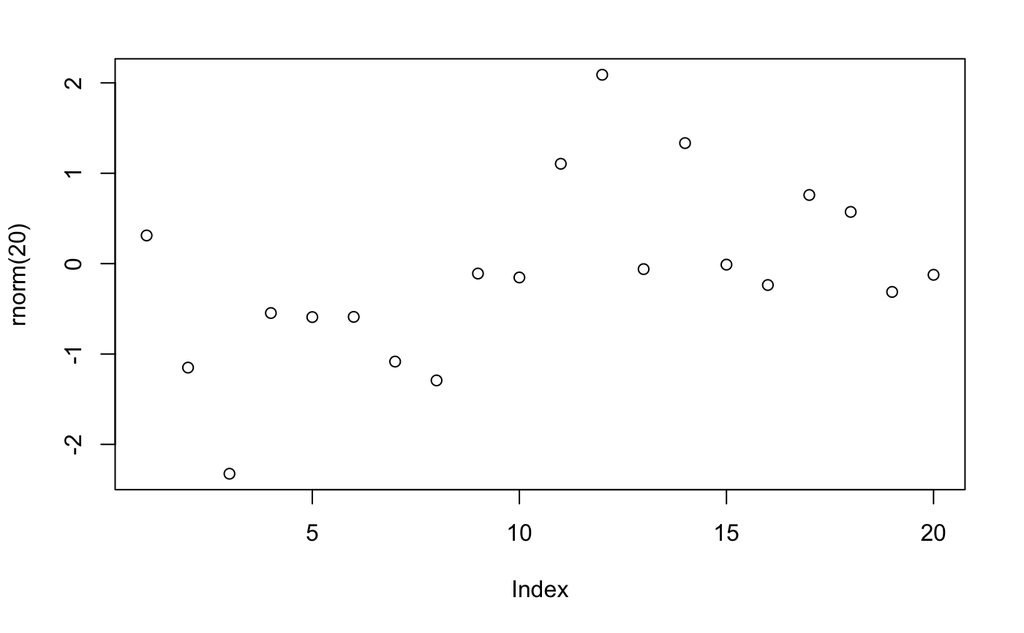

```r
plot(rnorm(20))
```

Hmm, I think it will easier to appreciate the properties of the normal distribution *(0 mean and 1 standard deviation)* with more points:

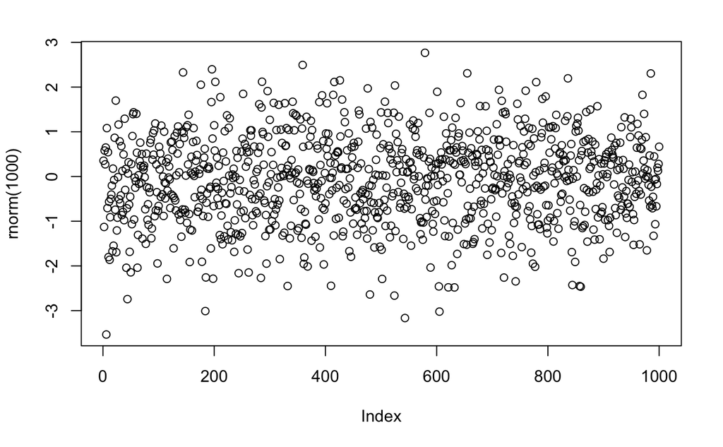

```r
plot(rnorm(1000))
```

For people interested in seeing the density function for these points:

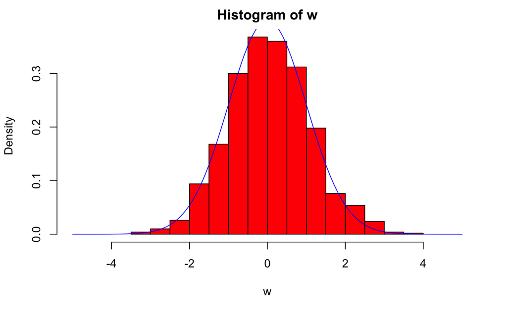

```r
w <- rnorm(1000)
hist(w, col = "red", freq = F, xlim = c(-5,5))
curve(dnorm, -5, 5, add = T, col = "blue")
```

Let’s introduce a function `abline(...)` which enables us to add horizontal and vertical lines to an existing plot:

```r
plot(x.norm)
# 'h' means horizontal line
# 'col' means color
abline(h = mean(x.norm), col = 'red')
```

```r
abline(h = median(x.norm), col = 'blue')
abline(h = mean(x.norm) + sd(x.norm), col = 'green')
```

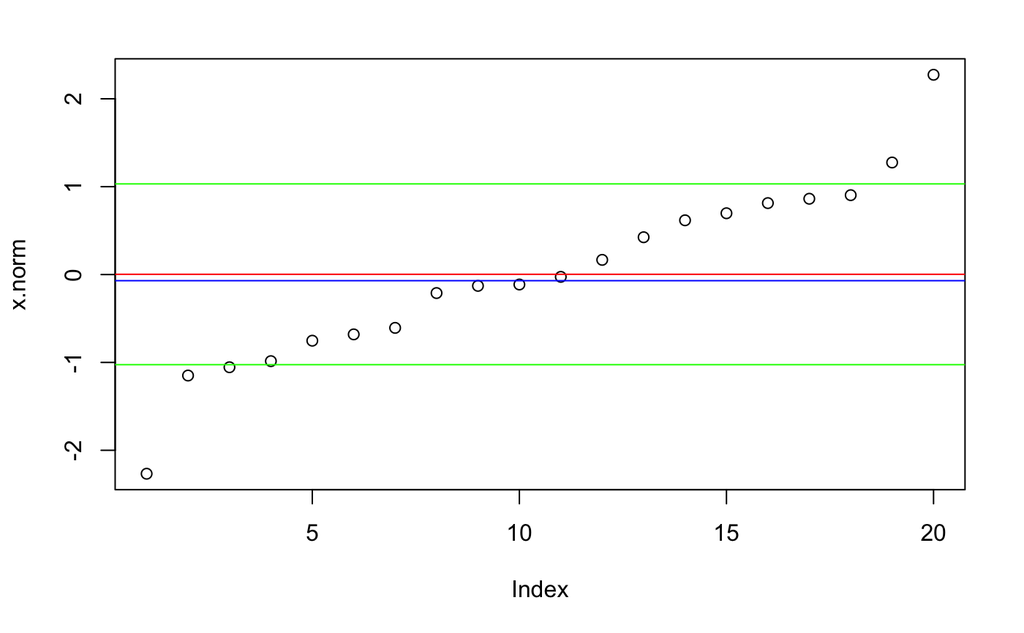

```r
abline(h = mean(x.norm) - sd(x.norm), col = 'green')
```

Let’s try to plot the quantiles from before:

```r
plot(x.norm)
abline(h = median(x.norm), col = 'blue')
```

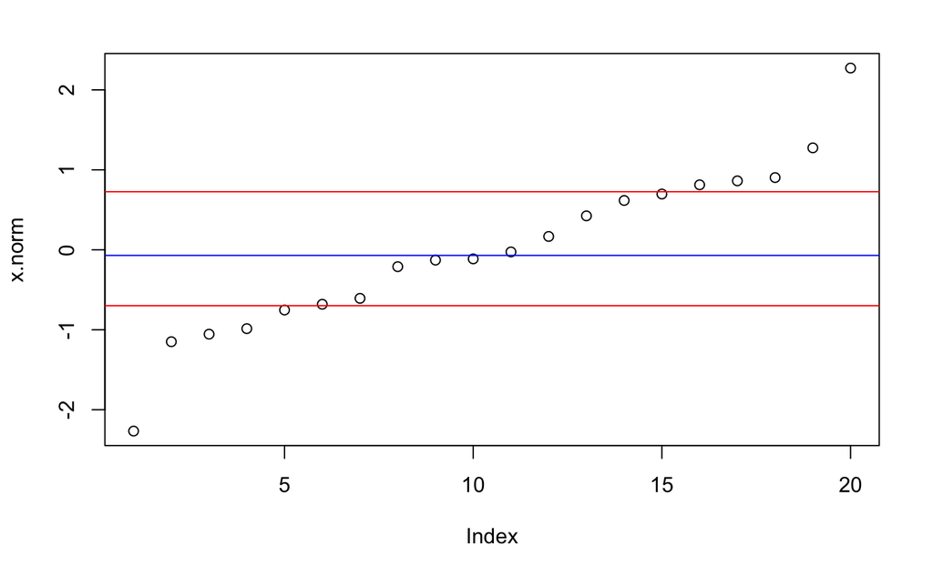

```r
abline(h = summary(x.norm)[2], col = 'red')
abline(h = summary(x.norm)[5], col = 'red')
```

# 3 Factors

## 3.1 Categorical Variables

The term factor refers to a statistical data type used to store categorical variables. The difference between a categorical variable and a continuous variable is that a categorical variable can belong to a limited number of categories. A continuous variable, on the other hand, can correspond to an infinite number of values. Let’s invoke the `factor(...)` function:

```r
# Language Codes
lang <- c("en","fr","hi","hi","ru","ru","ru","ru","fr","hi","en","cn")
# Factor of Language codes
langf <- factor(lang)
langf
```

```
 [1] en fr hi hi ru ru ru ru fr hi en cn
Levels: cn en fr hi ru
```

There are two types of categorical variables: a **nominal** categorical variable and an **ordinal** categorical variable. A nominal variable is a categorical variable without an implied order. This means that it is impossible to say that ‘one is worth more than the other’. While, the ordinal variable will have some inherent ordering. We’ve just seen an example of a nominal variable, let’s see an example of the ordinal variable:

```r
# Speed traps measuring car speeds
speed <- c("high","med","high","med","low")
# The ordering is given by specifying the levels
speedf <- factor(speed, ordered = TRUE, levels = c("low","med","high"))
speedf
```

```
[1] high med  high med  low
Levels: low < med < high
```

## 3.2 Levels

Notice also that there are no quotes around the values. That’s because they’re not strings; they’re actually integer references to one of the factor’s levels. But what is a *level*? It is simply the unique values in the vector:

```r
levels(speedf)
```

```
[1] "low"  "med"  "high"
```

Let’s try comparing ordered factors. In our previous example, we want to test whether the second car is going slower than the third car:

```r
# Ordered factors can compare strings
speedf[2] < speedf[3]
```

```
[1] TRUE
```

## 3.3 Frequency tables

Try calling `summary(...)` on every object from now on:

```r
# Returns frequencies
summary(langf)
```

```
cn en fr hi ru
 1  2  2  3  4
```

## 3.4 Tests for Factors

At this point, there are built-in functions that are similar for nearly every data structure, so don’t be surprised with a `is.factor(...)`:

```r
# Performs a check for factor
is.factor(langf)
```

```
[1] TRUE
```

Or, something like this:

```r
# Returns a vector
as.vector(langf)
```

```
 [1] "en" "fr" "hi" "hi" "ru" "ru" "ru" "ru" "fr" "hi" "en" "cn"
```

Or, this:

```r
# Returns a column
as.matrix(langf)
```

```
      [,1]
 [1,] "en"
 [2,] "fr"
 [3,] "hi"
 [4,] "hi"
 [5,] "ru"
 [6,] "ru"
 [7,] "ru"
 [8,] "ru"
 [9,] "fr"
[10,] "hi"
[11,] "en"
[12,] "cn"
```

# 4 Dataframes

## 4.1 Explore a Dataset

There are several built-in datasets within R. Arguably, the ‘Hello World’ example of these datasets is `mtcars`:

```r
# Motor Trend Car Road Tests
mtcars
```

|  | mpg | cyl | disp | hp | drat | wt | qsec | vs | am | gear | carb |
| --- | --- | --- | --- | --- | --- | --- | --- | --- | --- | --- | --- |
| Mazda RX4 | 21.0 | 6 | 160.0 | 110 | 3.90 | 2.620 | 16.46 | 0 | 1 | 4 | 4 |
| Mazda RX4 Wag | 21.0 | 6 | 160.0 | 110 | 3.90 | 2.875 | 17.02 | 0 | 1 | 4 | 4 |
| Datsun 710 | 22.8 | 4 | 108.0 | 93 | 3.85 | 2.320 | 18.61 | 1 | 1 | 4 | 1 |
| Hornet 4 Drive | 21.4 | 6 | 258.0 | 110 | 3.08 | 3.215 | 19.44 | 1 | 0 | 3 | 1 |
| Hornet Sportabout | 18.7 | 8 | 360.0 | 175 | 3.15 | 3.440 | 17.02 | 0 | 0 | 3 | 2 |
| Valiant | 18.1 | 6 | 225.0 | 105 | 2.76 | 3.460 | 20.22 | 1 | 0 | 3 | 1 |
| Duster 360 | 14.3 | 8 | 360.0 | 245 | 3.21 | 3.570 | 15.84 | 0 | 0 | 3 | 4 |
| Merc 240D | 24.4 | 4 | 146.7 | 62 | 3.69 | 3.190 | 20.00 | 1 | 0 | 4 | 2 |
| Merc 230 | 22.8 | 4 | 140.8 | 95 | 3.92 | 3.150 | 22.90 | 1 | 0 | 4 | 2 |
| Merc 280 | 19.2 | 6 | 167.6 | 123 | 3.92 | 3.440 | 18.30 | 1 | 0 | 4 | 4 |

[output cut: 22 more lines]

Let’s have a look at the top rows from this dataset using `head(...)`:

```r
# Top rows
head(mtcars)
```

|  | mpg | cyl | disp | hp | drat | wt | qsec | vs | am | gear | carb |
| --- | --- | --- | --- | --- | --- | --- | --- | --- | --- | --- | --- |
| Mazda RX4 | 21.0 | 6 | 160 | 110 | 3.90 | 2.620 | 16.46 | 0 | 1 | 4 | 4 |
| Mazda RX4 Wag | 21.0 | 6 | 160 | 110 | 3.90 | 2.875 | 17.02 | 0 | 1 | 4 | 4 |
| Datsun 710 | 22.8 | 4 | 108 | 93 | 3.85 | 2.320 | 18.61 | 1 | 1 | 4 | 1 |
| Hornet 4 Drive | 21.4 | 6 | 258 | 110 | 3.08 | 3.215 | 19.44 | 1 | 0 | 3 | 1 |
| Hornet Sportabout | 18.7 | 8 | 360 | 175 | 3.15 | 3.440 | 17.02 | 0 | 0 | 3 | 2 |
| Valiant | 18.1 | 6 | 225 | 105 | 2.76 | 3.460 | 20.22 | 1 | 0 | 3 | 1 |

Let’s have a look at the bottom rows from this dataset using `tail(...)`:

```r
# Bottom rows
tail(mtcars)
```

|  | mpg | cyl | disp | hp | drat | wt | qsec | vs | am | gear | carb |
| --- | --- | --- | --- | --- | --- | --- | --- | --- | --- | --- | --- |
| Porsche 914-2 | 26.0 | 4 | 120.3 | 91 | 4.43 | 2.140 | 16.7 | 0 | 1 | 5 | 2 |
| Lotus Europa | 30.4 | 4 | 95.1 | 113 | 3.77 | 1.513 | 16.9 | 1 | 1 | 5 | 2 |
| Ford Pantera L | 15.8 | 8 | 351.0 | 264 | 4.22 | 3.170 | 14.5 | 0 | 1 | 5 | 4 |
| Ferrari Dino | 19.7 | 6 | 145.0 | 175 | 3.62 | 2.770 | 15.5 | 0 | 1 | 5 | 6 |
| Maserati Bora | 15.0 | 8 | 301.0 | 335 | 3.54 | 3.570 | 14.6 | 0 | 1 | 5 | 8 |
| Volvo 142E | 21.4 | 4 | 121.0 | 109 | 4.11 | 2.780 | 18.6 | 1 | 1 | 4 | 2 |

Invoking `class(mtcars)` will tell us it’s an object of type `data.frame`. But let’s go a step further and explore the structure of the data frame using `str(...)`:

```r
# Returns the structure
str(mtcars)
```

```
'data.frame':   32 obs. of  11 variables:
 $ mpg : num  21 21 22.8 21.4 18.7 18.1 14.3 24.4 22.8 19.2 ...
 $ cyl : num  6 6 4 6 8 6 8 4 4 6 ...
 $ disp: num  160 160 108 258 360 ...
 $ hp  : num  110 110 93 110 175 105 245 62 95 123 ...
 $ drat: num  3.9 3.9 3.85 3.08 3.15 2.76 3.21 3.69 3.92 3.92 ...
 $ wt  : num  2.62 2.88 2.32 3.21 3.44 ...
 $ qsec: num  16.5 17 18.6 19.4 17 ...
 $ vs  : num  0 0 1 1 0 1 0 1 1 1 ...
 $ am  : num  1 1 1 0 0 0 0 0 0 0 ...
 $ gear: num  4 4 4 3 3 3 3 4 4 4 ...
 $ carb: num  4 4 1 1 2 1 4 2 2 4 ...
```

## 4.2 Creating Dataframes

Calling the `data.frame(...)` function enables us to create a dataframe. Notice the vector names become the column names automatically. Each data argument to the `data.frame(...)` function takes the form of either *value* or *tag = value*:

```r
# Definition of vectors
name <- c("Mercury", "Venus", "Earth", "Mars", "Jupiter", "Saturn", "Uranus", "Neptune")
type <- c("Terrestrial planet", "Terrestrial planet", "Terrestrial planet",
          "Terrestrial planet", "Gas giant", "Gas giant", "Gas giant", "Gas giant")
diameter <- c(0.382, 0.949, 1, 0.532, 11.209, 9.449, 4.007, 3.883)
rotation <- c(58.64, -243.02, 1, 1.03, 0.41, 0.43, -0.72, 0.67)
rings <- c(FALSE, FALSE, FALSE, FALSE, TRUE, TRUE, TRUE, TRUE)
# Create a data frame from the vectors
planets_df <- data.frame(name, type, diameter, rotation, rings)
planets_df
```

| name | type | diameter | rotation | rings |
| --- | --- | --- | --- | --- |
| Mercury | Terrestrial planet | 0.382 | 58.64 | FALSE |
| Venus | Terrestrial planet | 0.949 | -243.02 | FALSE |
| Earth | Terrestrial planet | 1.000 | 1.00 | FALSE |
| Mars | Terrestrial planet | 0.532 | 1.03 | FALSE |
| Jupiter | Gas giant | 11.209 | 0.41 | TRUE |
| Saturn | Gas giant | 9.449 | 0.43 | TRUE |
| Uranus | Gas giant | 4.007 | -0.72 | TRUE |
| Neptune | Gas giant | 3.883 | 0.67 | TRUE |

Let’s explore the structure once again:

```r
# Returns the structure of the planets
str(planets_df)
```

```
'data.frame':   8 obs. of  5 variables:
 $ name    : Factor w/ 8 levels "Earth","Jupiter",..: 4 8 1 3 2 6 7 5
 $ type    : Factor w/ 2 levels "Gas giant","Terrestrial planet": 2 2 2 2 1 1 1 1
 $ diameter: num  0.382 0.949 1 0.532 11.209 ...
 $ rotation: num  58.64 -243.02 1 1.03 0.41 ...
 $ rings   : logi  FALSE FALSE FALSE FALSE TRUE TRUE ...
```

## 4.3 Dataframe Access

Dataframes share a lot in common with matrices. Think of dataframes as extended matrices, without the necessity to contain elements of the same data type. However, there are a few quirks. Let’s try accessing some columns:

```r
# First column by index
planets_df[[1]]
```

```
[1] Mercury Venus   Earth   Mars    Jupiter Saturn  Uranus  Neptune
Levels: Earth Jupiter Mars Mercury Neptune Saturn Uranus Venus
```

```r
# First column by name
planets_df[['type']]
```

```
[1] Terrestrial planet Terrestrial planet Terrestrial planet Terrestrial planet Gas giant
[6] Gas giant          Gas giant          Gas giant
Levels: Gas giant Terrestrial planet
```

```r
# By using the '$' atomic vector
planets_df$diameter
```

```
[1]  0.382  0.949  1.000  0.532 11.209  9.449  4.007  3.883
```

## 4.4 Tests for Dataframes

TLDR, `is.data.frame(...)`:

```r
# Checks if 'planets_df' is a dataframe
is.data.frame(planets_df)
```

```
[1] TRUE
```

You can also coerce other objects into dataframes:

```r
# Coerces matrix to dataframe
as.data.frame(matrix(1:10, nrow = 5, ncol = 2, dimnames = list(NULL, c("X","Y"))))
```

| X | Y |
| --- | --- |
| 1 | 6 |
| 2 | 7 |
| 3 | 8 |
| 4 | 9 |
| 5 | 10 |

# 5 Practice! Practice! Practice!

## 5.1 Access by Indices

What’s the diameter of Mercury?

```r
# Print out diameter of Mercury (row 1, column 3)
planets_df[1,3]
```

```
[1] 0.382
```

Show me all the data for Mars!

```r
# Print out data for Mars (entire fourth row)
planets_df[4, ]
```

|  | name | type | diameter | rotation | rings |
| --- | --- | --- | --- | --- | --- |
| 4 | Mars | Terrestrial planet | 0.532 | 1.03 | FALSE |

## 5.2 Access by names

What are the diameters of all planets?

```r
# planets_df[['diameters']] is also valid
planets_df$diameter
```

```
[1]  0.382  0.949  1.000  0.532 11.209  9.449  4.007  3.883
```

What type of planets are the first 3 planets?

```r
# planets_df[1:3,"type"] is also valid
planets_df$type[1:3]
```

```
[1] Terrestrial planet Terrestrial planet Terrestrial planet
Levels: Gas giant Terrestrial planet
```

## 5.3 Access by logical vectors

Which planets have positive rotation?

```r
# planets_df[,'rotation'] > 0 is also valid
positive_rotation <- planets_df$rotation > 0
# Plantes with positive rotation
planets_df[positive_rotation,]
```

|  | name | type | diameter | rotation | rings |
| --- | --- | --- | --- | --- | --- |
| 1 | Mercury | Terrestrial planet | 0.382 | 58.64 | FALSE |
| 3 | Earth | Terrestrial planet | 1.000 | 1.00 | FALSE |
| 4 | Mars | Terrestrial planet | 0.532 | 1.03 | FALSE |
| 5 | Jupiter | Gas giant | 11.209 | 0.41 | TRUE |
| 6 | Saturn | Gas giant | 9.449 | 0.43 | TRUE |
| 8 | Neptune | Gas giant | 3.883 | 0.67 | TRUE |

Names of the planets that have positive rotation and rings:

```r
# Give yourself a cookie if you got this right!!!
planets_df[planets_df$rotation > 0 & planets_df$rings, 'name']
```

```
[1] Jupiter Saturn  Neptune
Levels: Earth Jupiter Mars Mercury Neptune Saturn Uranus Venus
```

# 6 Lists

## 6.1 Creating Lists

Lists, as opposed to vectors, can hold components of different types. These objects can be matrices, vectors, data frames, even other lists, etc. It is not even required that these objects are related to each other in any way.

```r
heroes <- c('Ironman', 'Thor', 'Captain America', 'Wonder Woman', 'Batman')
actors <- c('Sir Robert Downey Jr', 'Chris Hemsworth', 'Chris Evans', 'Gal Gadot', 'Christian Bale')
level <- c(100, 1000, 10, 10000, 100000)
# Initialise the list
super_heroes <- list(power_level = data.frame(heroes,level),
                     serial_no = 1:5,
                     actor_names = actors)
super_heroes
```

| heroes | level |
| --- | --- |
| Ironman | 1e+02 |
| Thor | 1e+03 |
| Captain America | 1e+01 |
| Wonder Woman | 1e+04 |
| Batman | 1e+05 |

```
$serial_no
[1] 1 2 3 4 5

$actor_names
[1] "Sir Robert Downey Jr" "Chris Hemsworth"      "Chris Evans"          "Gal Gadot"
[5] "Christian Bale"
```

## 6.2 Access for lists

We can access the elements in a list through indexing through double squared brackets `[[...]]`:

```r
# Displays the second element in the list
super_heroes[[2]]
```

[output not shown]

The list can be accessed through the named elements as well. Let’s use `names(...)` to see the named elements of the list:

```r
# Named elements of the list
names(super_heroes)
```

[output not shown]

There are two fundamental ways to access a list through names, here we use the element name:

```r
# Through element names
super_heroes[["serial_no"]]
```

```
[1] 1 2 3 4 5
```

And here we invoke the atomic vector

```r
super_heroes$power_level
```

| heroes | level |
| --- | --- |
| Ironman | 1e+02 |
| Thor | 1e+03 |
| Captain America | 1e+01 |
| Wonder Woman | 1e+04 |
| Batman | 1e+05 |

## 6.3 Test for list

The function `is.list(...)` tests for lists and returns a boolean value:

```r
is.list(super_heroes)
```

```
[1] TRUE
```

One can also coerce an object into a list using the function `as.list(...)`:

```r
# Create a dataframe
The_Simpsons <- data.frame(first_name = c("Bart","Lisa","Homer","Marge","Baby"),
                           last_name = rep("Simpson", 5))
The_Simpsons
```

| first_name | last_name |
| --- | --- |
| Bart | Simpson |
| Lisa | Simpson |
| Homer | Simpson |
| Marge | Simpson |
| Baby | Simpson |

```r
# Coercing a dataframe into a list
as.list(The_Simpsons)
```

```
$first_name
[1] Bart  Lisa  Homer Marge Baby
Levels: Baby Bart Homer Lisa Marge

$last_name
[1] Simpson Simpson Simpson Simpson Simpson
Levels: Simpson
```

But more often we will use `str(...)` to describe objects like lists:

```r
# Displays the entire structure of the list
str(super_heroes)
```

```
List of 3
 $ power_level:'data.frame':    5 obs. of  2 variables:
  ..$ heroes: Factor w/ 5 levels "Batman","Captain America",..: 3 4 2 5 1
  ..$ level : num [1:5] 1e+02 1e+03 1e+01 1e+04 1e+05
 $ serial_no  : int [1:5] 1 2 3 4 5
 $ actor_names: chr [1:5] "Sir Robert Downey Jr" "Chris Hemsworth" "Chris Evans" "Gal Gadot" ...
```